# Trabajo Practico 3

Fecha de publicación

18 de junio de 2026

Cargo los librerias necesarias y las pedidas en el enunciado

```r
#verifico si pacman ya existe, si no está lo instalo
if (!require("pacman")) install.packages("pacman", repos ="https://cloud.r-project.org")

pacman::p_load(here, tidyverse, broom, ggstats, marginaleffects, kableExtra, broom)
```

## *0. Preparación, carga y limpieza de datos*

Cargo la base de datos dada en la consigna

```r
datos_censo <- read_csv(here("TP3/data/adult_census_USA.csv"))
```

## *1. Análisis exploratorio y decisiones de transformación*

Una vez que pude cargar las bases, analizo las distintas variables que tiene y sus valores

```r
summary(datos_censo) #hago un resumen estadistico general
```

```
      age         workclass          education         education_num
 Min.   :17.00   Length:15766       Length:15766       Min.   : 1.00
 1st Qu.:31.00   Class :character   Class :character   1st Qu.: 9.00
 Median :40.00   Mode  :character   Mode  :character   Median :10.00
 Mean   :40.14                                         Mean   :10.57
 3rd Qu.:49.00                                         3rd Qu.:13.00
 Max.   :90.00                                         Max.   :16.00
 marital_status      occupation        relationship           race
 Length:15766       Length:15766       Length:15766       Length:15766
 Class :character   Class :character   Class :character   Class :character
 Mode  :character   Mode  :character   Mode  :character   Mode  :character



     sex             capital_gain    capital_loss    hours_per_week
 Length:15766       Min.   :    0   Min.   :   0.0   Min.   : 1.00
 Class :character   1st Qu.:    0   1st Qu.:   0.0   1st Qu.:40.00
 Mode  :character   Median :    0   Median :   0.0   Median :40.00
                    Mean   : 1952   Mean   : 119.9   Mean   :42.52
                    3rd Qu.:    0   3rd Qu.:   0.0   3rd Qu.:50.00
                    Max.   :99999   Max.   :4356.0   Max.   :99.00
 native_country        income
 Length:15766       Length:15766
 Class :character   Class :character
 Mode  :character   Mode  :character
```

Además exploro las variables que no tiene valores numericos, para asi poder interpretar como recodificar la base

```r
unique(datos_censo$workclass)
```

```
[1] "Private"          "Self-emp-not-inc" "State-gov"        "Federal-gov"
[5] "Local-gov"        "Self-emp-inc"     "Without-pay"
```

```r
unique(datos_censo$education)
```

```
 [1] "Bachelors"    "Masters"      "9th"          "HS-grad"      "Some-college"
 [6] "11th"         "Doctorate"    "Assoc-voc"    "Prof-school"  "5th-6th"
[11] "Assoc-acdm"   "7th-8th"      "10th"         "12th"         "1st-4th"
[16] "Preschool"
```

```r
unique(datos_censo$marital_status)
```

```
[1] "Married-civ-spouse"    "Married-spouse-absent" "Never-married"
[4] "Divorced"              "Separated"             "Widowed"
[7] "Married-AF-spouse"
```

```r
unique(datos_censo$occupation)
```

```
 [1] "Prof-specialty"    "Exec-managerial"   "Other-service"
 [4] "Sales"             "Farming-fishing"   "Transport-moving"
 [7] "Tech-support"      "Craft-repair"      "Machine-op-inspct"
[10] "Adm-clerical"      "Protective-serv"   "Handlers-cleaners"
[13] "Armed-Forces"      "Priv-house-serv"
```

```r
unique(datos_censo$race)
```

```
[1] "Black"              "White"              "Asian-Pac-Islander"
[4] "Amer-Indian-Eskimo" "Other"
```

```r
unique(datos_censo$sex)
```

```
[1] "Female" "Male"
```

```r
unique(datos_censo$income)
```

```
[1] "<=50K" ">50K"
```

En base a esta exploración podemos ver que hay algunas variables, como *marital_status* y *education*, que tienen muchas categorías. En base a esto, agrupo en categorias mas grandes, para que el modelo no sea difícil de interpretar y evitar que se arruine la estimación.

### Recodificación de las variables

```r
datos_ajustados <- datos_censo %>%
  # 1. ordeno los niveles de income (lo pide la consigna)
  mutate(income = factor(income, levels = c("<=50K", ">50K"))) %>%

  # 2. recodifico el estado civil (de 7 categorías a 2 principales; casada o soltera)
  mutate(marital_status_2 = case_when(
    marital_status %in% c("Married-civ-spouse", "Married-AF-spouse") ~ "Married",
    marital_status %in% c("Never-married", "Divorced", "Separated", "Widowed", "Married-spouse-absent") ~ "Single"
  )) %>%
  mutate(marital_status_2 = as.factor(marital_status_2)) %>%

  # 3. recodifico la educación (Agrupo los 16 niveles según nivel alcanzado; 4 categorías)
  mutate(education_2 = case_when(
    education %in% c("Preschool", "1st-4th", "5th-6th", "7th-8th", "9th", "10th", "11th", "12th") ~ "School",
    education %in% c("HS-grad", "Some-college") ~ "High_School_or_Some_College",
    education %in% c("Bachelors", "Assoc-voc", "Assoc-acdm") ~ "Undergraduate",
    education %in% c("Masters", "Doctorate", "Prof-school") ~ "Postgraduate"
  )) %>%
  mutate(education_2 = factor(education_2,
                                  levels = c("School", "High_School_or_Some_College", "Undergraduate", "Postgraduate"))) %>%

  # 4. paso sexo a factor (Para que el modelo lo tome correctamente)
  mutate(sex = as.factor(sex))
```

### Gráfico 1

Para ver la relación entre las variables continuas uso un grafico de densidad. Con este puedo ver si la gente con ingresos mayores a 50k tiende a concentrarse en edades mas avanzadas que la gente de menores ingresos.

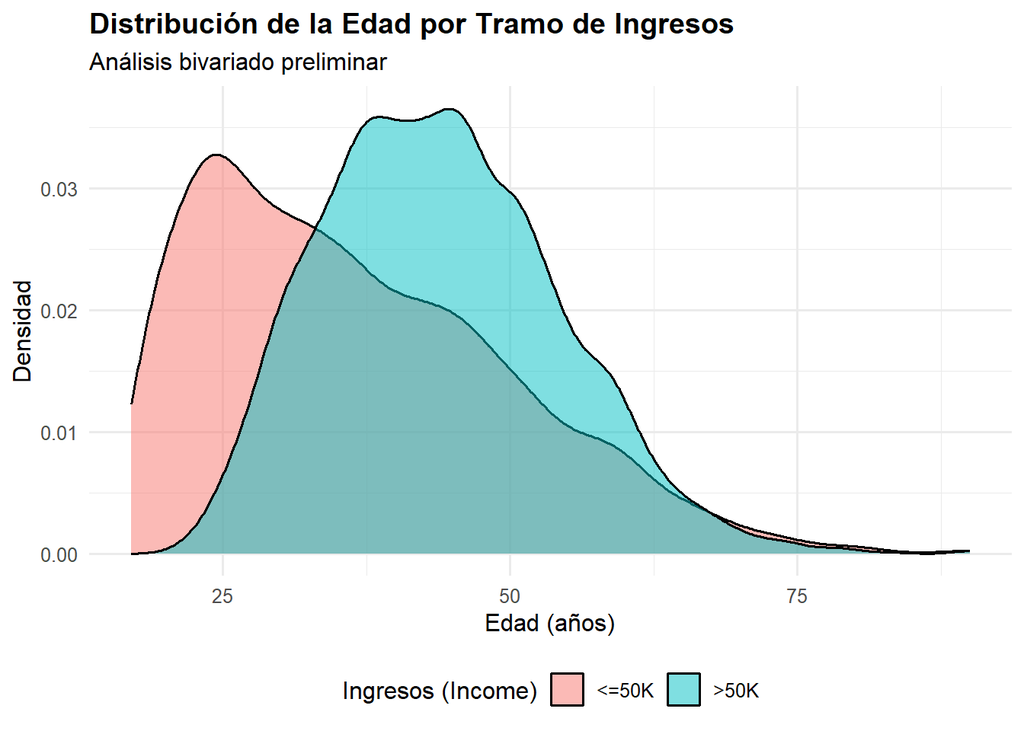

```r
ggplot(datos_ajustados, aes(x = age, fill = income)) +
  geom_density(alpha = 0.5) +
  theme_minimal(base_size = 12) +
  labs(
    title = "Distribución de la Edad por Tramo de Ingresos",
    subtitle = "Análisis bivariado preliminar",
    x = "Edad (años)",
    y = "Densidad",
    fill = "Ingresos (Income)"
  ) +
  theme(
    legend.position = "bottom",
    plot.title = element_text(face = "bold")
  )
```

El gráfico muestra claramente que la población con ingresos menores o iguales a 50K (curva rosa) es mucho más joven, concentrando su pico cerca de los 25 años y cayendo rápidamente. En cambio, quienes ganan más de 50K (curva celeste) se distribuyen en edades más maduras, formando una meseta entre los 35 y los 50 años.

### Gráfico 2

En el segundo gráfico uso el modelo de barras aplicadas para poder ver la variables categóricas. Con el *position = fill* puedo comparar directamente la proporcion de personas que ganan mas de 50k en cada nivel educativo, sin que afecte el hecho de que haya más estudiantes que graduados en la muestra

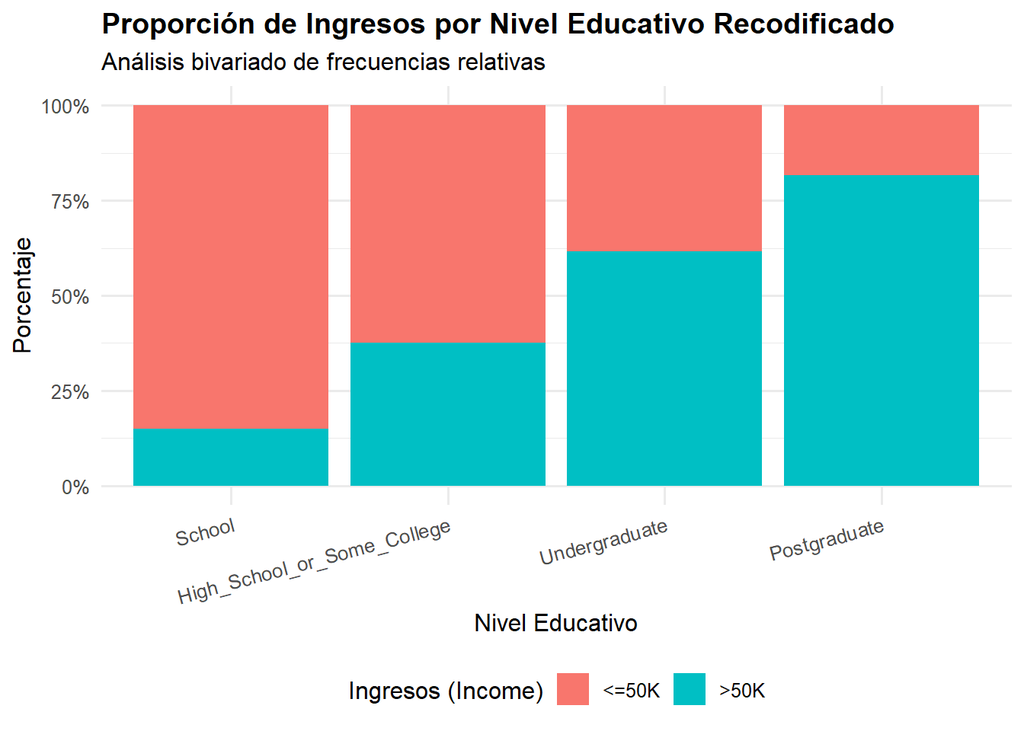

Figura 1: Proporción de niveles de ingresos según educación alcanzada

```r
ggplot(datos_ajustados, aes(x = education_2, fill = income)) +
  # position = "fill" transforma las barras en porcentajes (proporciones)
  geom_bar(position = "fill") +
  # eje Y en formato de porcentaje (0% a 100%)
  scale_y_continuous(labels = scales::label_percent()) +
  theme_minimal(base_size = 12) +
  labs(
    title = "Proporción de Ingresos por Nivel Educativo Recodificado",
    subtitle = "Análisis bivariado de frecuencias relativas",
    x = "Nivel Educativo",
    y = "Porcentaje",
    fill = "Ingresos (Income)"
  ) +
  theme(
    legend.position = "bottom",
    plot.title = element_text(face = "bold"),
    axis.text.x = element_text(angle = 15, hjust = 1) # inclino el texto para que no se pise
  )
```

Al estandarizar todas las barras al 100%, se ve un salto drástico y escalonado: a mayor nivel educativo, la proporción celeste (ganar más de 50K) crece enormemente. Mientras que en la categoría “School” apenas roza el 15%, en los graduados universitarios (“Undergraduate”) supera el 50% y en los posgrados (“Postgraduate”) alcanza casi el 80%.

### Gráfico 3

Hago un gráfico de visualización bivariada para poder ver las distribuciones de hora trabajadas segín el sexo de las personas.

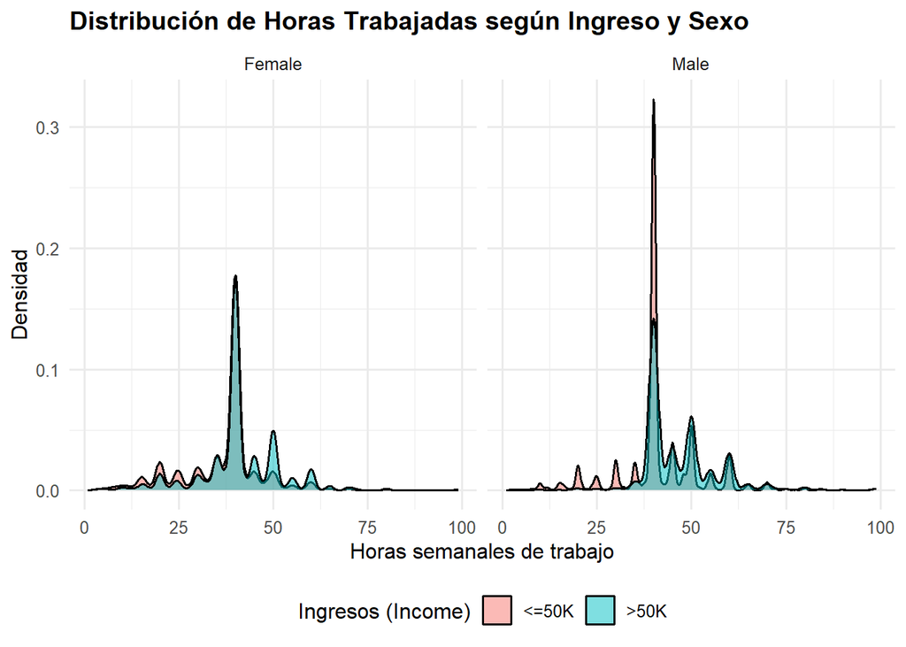

Figura 2: Distribución de horas semanales por tramo de ingresos y sexo

```r
ggplot(datos_ajustados, aes(x = hours_per_week, fill = income)) +
  geom_density(alpha = 0.5) +
  facet_wrap(~ sex) +  # Abre el gráfico en paneles por sexo
  theme_minimal(base_size = 12) +
  labs(
    title = "Distribución de Horas Trabajadas según Ingreso y Sexo",
    x = "Horas semanales de trabajo",
    y = "Densidad",
    fill = "Ingresos (Income)"
  ) +
  theme(
    legend.position = "bottom",
    plot.title = element_text(face = "bold")
  )
```

Al graficar esta interacción se puede ver una gran diferencia entre sexos. El panel de los hombres es más disperso y cubre más base hacia la derecha, por lo tanto, a medida que suman más horas laborales, tienen una tendencia mayor (comparando con las mujeres) a recibir mayores salarios.

## *2. Ajustes de Modelos*

Antes de ajustar los modelos, es importante determinar cuales son las categorias de referencia (de base) para las variables categóricas:

- Para genero: Female
- Para el nivel educativo: School (porque es el nivel de educación mas bajo)

Entonces, en ambos modelos el intercept representa el valor esperado para una mujer que tiene *School* como nivel máximo de estudios

#### **Modelo 1**

Armo la regresión para el primer gráfico

```r
#|label: modelo-1

modelo_1 <- glm(income ~ age + sex + hours_per_week + education_2, data = datos_ajustados, family = binomial)

print(modelo_1)
```

```
Call:  glm(formula = income ~ age + sex + hours_per_week + education_2,
    family = binomial, data = datos_ajustados)

Coefficients:
                           (Intercept)                                     age
                              -6.36396                                 0.05000
                               sexMale                          hours_per_week
                               1.15649                                 0.03698
education_2High_School_or_Some_College                education_2Undergraduate
                               1.38555                                 2.44196
               education_2Postgraduate
                               3.20616

Degrees of Freedom: 15765 Total (i.e. Null);  15759 Residual
Null Deviance:      21820
Residual Deviance: 16850    AIC: 16860
```

```r
summary(modelo_1)
```

```
Call:
glm(formula = income ~ age + sex + hours_per_week + education_2,
    family = binomial, data = datos_ajustados)

Coefficients:
                                        Estimate Std. Error z value Pr(>|z|)
(Intercept)                            -6.363960   0.141487  -44.98   <2e-16
age                                     0.050002   0.001632   30.63   <2e-16
sexMale                                 1.156489   0.045600   25.36   <2e-16
hours_per_week                          0.036978   0.001846   20.03   <2e-16
education_2High_School_or_Some_College  1.385551   0.082388   16.82   <2e-16
education_2Undergraduate                2.441960   0.086160   28.34   <2e-16
education_2Postgraduate                 3.206164   0.100350   31.95   <2e-16

(Intercept)                            ***
age                                    ***
sexMale                                ***
hours_per_week                         ***
education_2High_School_or_Some_College ***
education_2Undergraduate               ***
education_2Postgraduate                ***
---
Signif. codes:  0 '***' 0.001 '**' 0.01 '*' 0.05 '.' 0.1 ' ' 1

(Dispersion parameter for binomial family taken to be 1)

    Null deviance: 21821  on 15765  degrees of freedom
Residual deviance: 16848  on 15759  degrees of freedom
AIC: 16862

Number of Fisher Scoring iterations: 4
```

Interpretaciones

A simple vista, se puede ver que todas las variables que puse en el modelo son estadisticamente significativas (p-valor menor a 0.0001). Haciendo un analisis mas detallado de cada variable podemos ver:

- Edad: manteniendo al resto de las variables constantes, por cada año adicional de edad, la probabilidad de ganar más de 50k aumenta en 0.05. Esto muestra una relación positiva y significata, a mayor edad y experiencia acumulada, mayor probabilidad de estar dentro del grupo de ingresos altos.
- Género: Con esta variable se puede ver que hay una gran diferencia entre hombres y mujeres. Los hombres muestran una probabilidad de ganar más de 50k que es 1.156 unidades mayor en comparación con las mujeres. Por lo tanto, se evidencia una gran brecha de genero en el mercado laboral, donde los hombres tienen mayores chances de tener ingresos altos a igualdad de edad, educación y horas de trabajo.
- Horas semanales: Manteniendo el resto de las variables constantes, cada hora adicional trabajada por semana, la probabilidad de superar los 50k aumenta 0.037. Osea, estadísticamente, a mas horas de trabajo hay mayor probabilidad de altos ingresos.

Nivel educativo: con esta variable se puede ver un efecto creciente a medida que aumenta el nivel educativo de los individuos (puse la categoria School como base, ya que es el nivel de educación mas bajo):

- Los que alcanzaron High School or Some College incrementan su probabilidad en 1.385 respespecto a la base
- Los que estan en Undergraduate (tienen un título) aumentan su probabilidad en 2.441
- Por ultimo, los que estan en Postgraduate (tienen un posgrado) son los que tienen el mayor aumento, con 3.206. Con esto podemos ver que alcanzar mayores niveles de educación es uno de los factores más determinantes para acceder al grupo de ingresos altos.

#### **Modelo 2**

Para este modelo segundo modelo quise usar la interacción entre el genero y las horas semanales. Esto lo hice para ver si el rendimiento del esfuerzo en el trabajo (medido por las horas que le dedican) se traducen de igual manera en la probabilidad de alcanzar ingresos altos para hombres y mujeres, teniendo en cuenta las posibles desigualdades o brechas de genero en el salario.

```r
modelo_interaccion <- glm(income ~ age + education_2 + sex*hours_per_week, data = datos_ajustados, family = binomial)

print(modelo_interaccion)
```

```
Call:  glm(formula = income ~ age + education_2 + sex * hours_per_week,
    family = binomial, data = datos_ajustados)

Coefficients:
                           (Intercept)                                     age
                              -5.78517                                 0.04990
education_2High_School_or_Some_College                education_2Undergraduate
                               1.38184                                 2.44509
               education_2Postgraduate                                 sexMale
                               3.21711                                 0.36760
                        hours_per_week                  sexMale:hours_per_week
                               0.02256                                 0.01930

Degrees of Freedom: 15765 Total (i.e. Null);  15758 Residual
Null Deviance:      21820
Residual Deviance: 16830    AIC: 16840
```

```r
summary(modelo_interaccion)
```

```
Call:
glm(formula = income ~ age + education_2 + sex * hours_per_week,
    family = binomial, data = datos_ajustados)

Coefficients:
                                        Estimate Std. Error z value Pr(>|z|)
(Intercept)                            -5.785169   0.186529 -31.015  < 2e-16
age                                     0.049905   0.001630  30.623  < 2e-16
education_2High_School_or_Some_College  1.381837   0.082533  16.743  < 2e-16
education_2Undergraduate                2.445089   0.086295  28.334  < 2e-16
education_2Postgraduate                 3.217106   0.100557  31.993  < 2e-16
sexMale                                 0.367596   0.176385   2.084   0.0372
hours_per_week                          0.022563   0.003593   6.280 3.38e-10
sexMale:hours_per_week                  0.019298   0.004184   4.613 3.98e-06

(Intercept)                            ***
age                                    ***
education_2High_School_or_Some_College ***
education_2Undergraduate               ***
education_2Postgraduate                ***
sexMale                                *
hours_per_week                         ***
sexMale:hours_per_week                 ***
---
Signif. codes:  0 '***' 0.001 '**' 0.01 '*' 0.05 '.' 0.1 ' ' 1

(Dispersion parameter for binomial family taken to be 1)

    Null deviance: 21821  on 15765  degrees of freedom
Residual deviance: 16827  on 15758  degrees of freedom
AIC: 16843

Number of Fisher Scoring iterations: 4
```

Interpretaciones

En base a esta regresión, podemos ver que el coeficiente de esta interacción es positivo y muy significativo, lo que demuestra que el efecto de trabajar más horas sobre la probabilidad de ganar más de 50k anuales no es igual para hombres que para mujeres.

Entonces, al incluir la interacción, los coeficientes cambian su interpretación:

- Horas semanales: este resultado ahora representa el efecto de las horas de trabajo exclusivamente para las mujeres (la categorá de referencia de género es femenina). Manteniendo la edad y la educación constante, por cada hora adicional por semana que trabaja una mujer, su probabilidad de ganar más de 50k aumenta en 0.0225
- Género: con la interacción, este coeficiente representa la brecha de género únicamente para personas que trabajan 0 horas semanales. Si bien es positivo y significativo (muy bajo), carece de interpretacion real por la ausencia de observaciones en cero horas.
- Término de interacción: con este coeficiente podemos ver el cambio en el efecto de las horas semanales cuando pasamos de mujeres a hombres. Para los hombres, el efecto de cada hora adicional de trabajo sobre la probabilidad de altos ingresos es la suma de ambos coeficientes: 0.0225 + 0.0193 = 0.0418. Con este resultado podemos ver que, cada hora extra trabajada incrementa la probabilidad de altos ingresos de forma mas fuerte en los hombres que en las mujeres.
- Educación y edad: los coeficientes de la edad y de los niveles educativos (los 3) mantienen la misma magnitud, siendo positivos y altamente significativo, como en el modelo1, demostrando la robustez de esos predictores.

## *3. Interpretación de resultados y efectos marginales*

#### Tabla de Efectos Marginales Promedio (AME)

IMPORTANTE: en el segundo modelo lo que veiamos eran los coeficientes “log-odds”. El tema con estos resultados es que son difíciles de entender en la vida real y se vuelven muy complicados cuando se cruzan variables.

Para solucionar esto y hacer el informa más claro, usamos los Efectos Marginales Promedio. Con este se puede traducir todo ese problema matemático a porcentaje de probabilidad real, así poder ver directamente cuánto sube o baja la probabilidad de ganar bien según cada variable, de forma más sencilla.

```r
efectos_marginales <- avg_slopes(modelo_interaccion) #calculo el AME

efectos_marginales %>% as_tibble() %>%
  select(term, contrast, estimate, std.error, p.value) %>%
  knitr::kable(
    digits = 4,
    col.names = c("Variable", "Contraste / Cambio", "Efecto Marginal (AME)", "Error Estándar", "p-valor"),
    caption = "Efectos Marginales Promedio (AME) - Modelo Interactivo"
  )
```

Efectos Marginales Promedio (AME) - Modelo Interactivo

| Variable | Contraste / Cambio | Efecto Marginal (AME) | Error Estándar | p-valor |
| --- | --- | --- | --- | --- |
| age | dY/dX | 0.0089 | 0.0003 | 0 |
| education_2 | High_School_or_Some_College - School | 0.2275 | 0.0108 | 0 |
| education_2 | Postgraduate - School | 0.5792 | 0.0138 | 0 |
| education_2 | Undergraduate - School | 0.4419 | 0.0116 | 0 |
| hours_per_week | dY/dX | 0.0067 | 0.0003 | 0 |
| sex | Male - Female | 0.2223 | 0.0082 | 0 |

Mirando la tabla de Efactos Marginales se puede ver el impacto real de cada una de las bariables en el salario que estas van a tener:

- Edad: A igual educación y horas de trabajo, por cada año más de edad que cumple una persona, su probabilidad de ganar más de 50K sube en promedio un 0.89%. Osea, la experiencia importa
- Horas semanales: En promedio, por cada hora extra que una persona trabaja a la semana, su probabilidad de tener un sueldo alto sube un 0.67%
- Género: a igualdad edad, educación y horas trabajadas, los hombres tienen en promedio un 22.23% más de probabilidad de ganar más de 50K que las mujeres. Esto deja ver la gran brecha de género que queda marcada en la disparidad de ingresos.
- Educación: En la educación se puede ver el mayor impacto. Si comparamos a las personas con quines solo fueron a la escuela básica (la categorá base):
  - Tener secundario o algo de universidad sube la probabildad de ganar sobre 50K en 22.75%
  - Tener un título universitario de grado sube esa probabilidad en un 44.19%
  - Tener un posgrado aumenta significativamente las probabilidades en un 57.92%

#### Gráfico Bosque

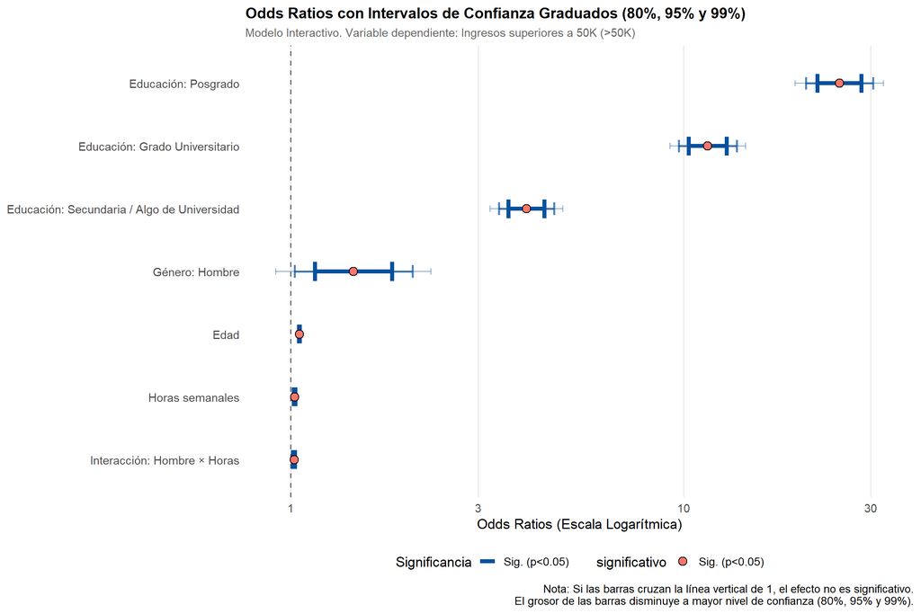

```r
datos_plot <- broom::tidy(modelo_interaccion) %>%
  filter(term != "(Intercept)") %>%
  mutate(
    estimado      = exp(estimate),
    low_99  = exp(estimate - 2.576 * std.error),
    high_99 = exp(estimate + 2.576 * std.error),
    low_95  = exp(estimate - 1.96 * std.error),
    high_95 = exp(estimate + 1.96 * std.error),
    low_80  = exp(estimate - 1.282 * std.error),
    high_80 = exp(estimate + 1.282 * std.error),
    etiqueta = case_match(
      term,
      "age"                                    ~ "Edad",
      "sexMale"                                ~ "Género: Hombre",
      "hours_per_week"                         ~ "Horas semanales",
      "education_2High_School_or_Some_College" ~ "Educación: Secundaria / Algo de Universidad",
      "education_2Undergraduate"                ~ "Educación: Grado Universitario",
      "education_2Postgraduate"                 ~ "Educación: Posgrado",
      "sexMale:hours_per_week"                 ~ "Interacción: Hombre × Horas"
    ),
    significativo = ifelse(p.value < 0.05, "Sig. (p<0.05)", "No sig.")
  )%>%  #los quise ordenar segun su valor, porque sino se orden alfabeticamente
  arrange(estimado) %>%
  mutate(etiqueta = factor(etiqueta, levels = unique(etiqueta)))

ggplot(
  datos_plot,
  aes(
    x     = estimado,
    y     = etiqueta,
    color = significativo
  )
) +
  geom_vline(
    xintercept = 1,
    linetype   = "dashed",
    color      = "gray40",
    linewidth  = 0.7
  ) +
  geom_errorbarh(
    aes(xmin = low_99, xmax = high_99),
    height    = 0.1,
    linewidth = 0.4,
    alpha     = 0.5
  ) +
  geom_errorbarh(
    aes(xmin = low_95, xmax = high_95),
    height    = 0.2,
    linewidth = 0.9,
    alpha     = 0.7
  ) +
  geom_errorbarh(
    aes(xmin = low_80, xmax = high_80),
    height    = 0.3,
    linewidth = 1.8
  ) +
  geom_point(
    aes(fill = significativo),
    shape = 21,
    color = "black",
    size  = 3.5
  ) +
  scale_x_log10() +
  scale_color_manual(
    values = c("Sig. (p<0.05)" = "#08519C", "No sig." = "#CB181D"),
    name   = "Significancia"
  ) +
  labs(
    title    = "Odds Ratios con Intervalos de Confianza Graduados (80%, 95% y 99%)",
    subtitle = "Modelo Interactivo. Variable dependiente: Ingresos superiores a 50K (>50K)",
    x        = "Odds Ratios (Escala Logarítmica)",
    y        = NULL,
    caption  = "Nota: Si las barras cruzan la línea vertical de 1, el efecto no es significativo.\nEl grosor de las barras disminuye a mayor nivel de confianza (80%, 95% y 99%)."
  ) +
  theme_minimal(base_size = 13) +
  theme(
    plot.title       = element_text(face = "bold", size = 14),
    plot.subtitle    = element_text(size = 11, color = "gray40"),
    axis.text.y      = element_text(size = 11),
    axis.text.x      = element_text(size = 11),
    legend.position  = "bottom",
    panel.grid.minor = element_blank(),
    panel.grid.major.y = element_blank()
  )
```

Interpretaciones:

Analizando más en profundidad cada una de las variables podemos llegar a distintas conclusiones. En primer lugar, podemos ver que la educación tiene un peso muy grande, ya que es por lejos la mas influyente. Las personas con Posgrado tienen la ventaja más grande de todas (su Odds Ratio se dispara cerca de 25), le siguen los graduados de grado universitario (alrededor de 11) y luego secundaria/algo de universidad (alrededor de 4).

En segundo lugar, la variable de género muestra la brecha que hay entre ambos sexos, como ya venimos mencionando anteriormente. Ser hombre está claramente a la derecha del 1 (cerca del 1.5). Esto muestra que, a igual edad y educación, los hombres tienen un 50% más de chances de estar en el grupo de ingresos altos que las mujeres.

Por ultimo, la edad, las horas semanales y la interaccion de ambas estan bastante pegados a la línea del 1. Esto puede ser porque se mide “año por año” o “hora por hora” y el salto númerico es más chico.

## *4. Comparación global de modelos*

```r
comparacion_global <- bind_rows(
  glance(modelo_1) %>%
    mutate(modelo = "Modelo 1"),
  glance(modelo_interaccion) %>%
    mutate(modelo = "Modelo 2")) %>%
  mutate(
    r2 = 1 - (deviance / null.deviance)) %>%
  select(modelo, AIC, deviance, null.deviance, r2)

comparacion_global %>%
  kable(digits = 4,
        col.names = c("Modelo", "AIC", "Deviance residual", "Deviance nula", "R²"),
        caption = "Comparación global: Modelo 1 y Modelo 2") %>%
  kable_styling(full_width = FALSE, bootstrap_options = c("striped", "hover"))
```

Comparación global: Modelo 1 y Modelo 2

| Modelo | AIC | Deviance residual | Deviance nula | R² |
| --- | --- | --- | --- | --- |
| Modelo 1 | 16861.90 | 16847.90 | 21820.63 | 0.2279 |
| Modelo 2 | 16842.92 | 16826.92 | 21820.63 | 0.2289 |

Interpretación

Al mirar los resultados de la tabla, queda muy claro que el Modelo 2 (el interactivo) es el ganador para explicar los ingresos de las personas. Esto lo vemos primero en el AIC, que baja de 16861.90 a 16842.92; en estadística, un AIC más chico significa que el modelo es más eficiente porque logra explicar mejor la realidad sin complicar las cosas de más.

Por último, el R² confirma esta mejora al subir a 0.2289, lo que significa que con el modelo 2 podemos ver una mayor porción de la variabilidad total de los ingresos.

Sin embargo, aunque el Modelo 2 es estadísticamente mejor porque mejora todas las métricas globales, la realidad es que agregar esa interacción no genera tanta diferencia; ambos modelos son casi idénticos a la hora de predecir los ingresos.

## *Conclusiones finales*

Al mirar los resultados globales, el Modelo 2 (el interactivo) es estadísticamente el ganador porque mejora todas las métricas, aunque en la práctica la diferencia con el Modelo 1 es mínima y ambos predicen los ingresos de forma casi idéntica. El aporte tan chico de la interacción tiene sentido si pensamos que mide el impacto de una sola hora extra de trabajo. Aunque ese valor parezca bajo de forma individual, se vuelve importante cuando se acumula en personas que hacen jornadas laborales largas.

En resumen, aunque variables como el género, las horas de trabajo o la edad le suman matices interesantes al análisis, el verdadero salto en los ingresos lo da la educación. Tener un mayor nivel de estudio demostró ser, sin lugar a dudas, el factor más determinante y el principal motor para acceder a un sueldo alto en esta muestra.